# Exploratory Data Analysis and Prediction of CarPrice Data

07-11-2022

## Introduction

- In this current generation car has become one of the most important things in human life.
- When we talk about a thing, automatically the first question is asked about it’s price.
- In this project I will do Exploratory Data Analysis and Prediction of car price.

## Objective

In this project my two prior objectives are

- To do Exploratory Data Analysis(EDA) .
- To predict price of car.

## Description of Dataset

- Source : https://www.kaggle.com/code/padminisaranyakadali/carpriceprediction/notebook
- Number of data points : 205
- Number of Variables : 24
- Number of Continuous Variable : 13
- Number of Discrete Variable : 1
- Number of Nominal Categorical Variable : 8
- Number of Ordinal Categorical Variable : 2

| Name of Variable | Description |
| --- | --- |
| CarName | Name of the car |
| fueltype | type of fuel |
| aspiration | aspiration type of car |
| doornumber | number of door |
| carbody | type of carbody |
| drivewheel | type of drivewheel |
| enginelocation | location of engine |
| wheelbase | base of wheel |
| carlength | length of car |
| carwidth | width of car |
| carheight | height of car |
| curbweight | weight of curb |
| enginetype | type of engine |
| cylindernumber | number of cylinder |
| enginesize | size of engine |
| fuelsystem | type of fuelsystem |
| boreratio | bore ratio of car |
| stroke | stroke of car |
| compressionratio | compression ratio of car |
| horsepower | horsepower of car |
| peakrpm | Maximum value of RPM of car |
| citympg | The score a car will get on average in city conditions, with stopping and starting at lower speeds |
| highwaympg | the average a car will get while driving on an open stretch ofroad without stopping or starting, typically at a higher speed. |
| price | price of car |

## Checking the Presence of Missing Values

- In the dataset, there is no missing value.

## Analysis of Numerical Variables

- Let us first report the values of average, variability and skewness of each of the variables.

|  | Mean | Median | sd | IQR | Skewness |
| --- | --- | --- | --- | --- | --- |
| wheelbase | 98.756585 | 97.00 | 6.0217757 | 7.90 | 1.0425136 |
| carlength | 174.049268 | 173.20 | 12.3372885 | 16.80 | 0.1548103 |
| carwidth | 65.907805 | 65.50 | 2.1452039 | 2.80 | 0.8973753 |
| carheight | 53.724878 | 54.10 | 2.4435220 | 3.50 | 0.0626599 |
| curbweight | 2555.565854 | 2414.00 | 520.6802035 | 790.00 | 0.6764022 |
| enginesize | 126.907317 | 120.00 | 41.6426934 | 44.00 | 1.9333748 |
| boreratio | 3.329756 | 3.31 | 0.2708437 | 0.43 | 0.0200086 |
| stroke | 3.255415 | 3.29 | 0.3135970 | 0.30 | -0.6846477 |
| compressionratio | 10.142537 | 9.00 | 3.9720403 | 0.80 | 2.5917196 |
| horsepower | 104.117073 | 95.00 | 39.5441668 | 46.00 | 1.3950064 |
| peakrpm | 5125.121951 | 5200.00 | 476.9856431 | 700.00 | 0.0746077 |
| citympg | 25.219512 | 24.00 | 6.5421417 | 11.00 | 0.6588378 |
| highwaympg | 30.751220 | 30.00 | 6.8864431 | 9.00 | 0.5360379 |
| price | 13276.710571 | 10295.00 | 7988.8523317 | 8715.00 | 1.7646442 |

- To understand the skewness graphically, we plot histogram of every numerical variables.

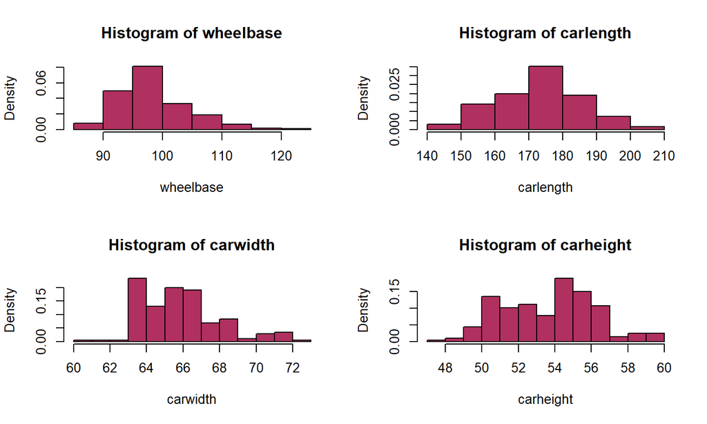

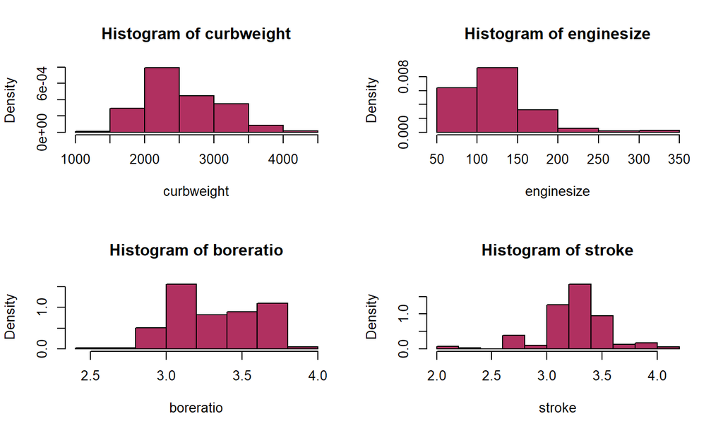

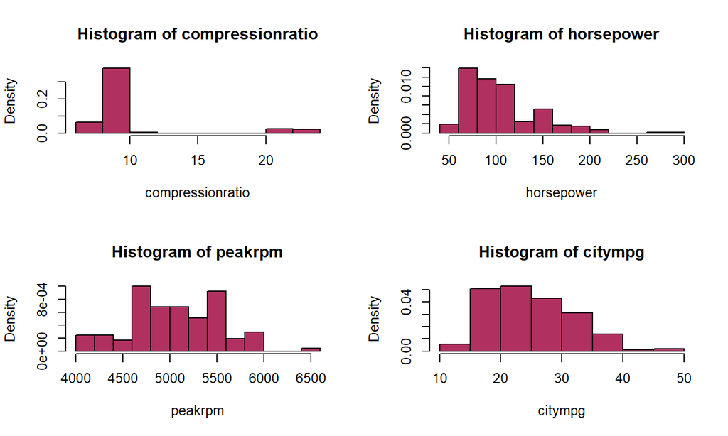

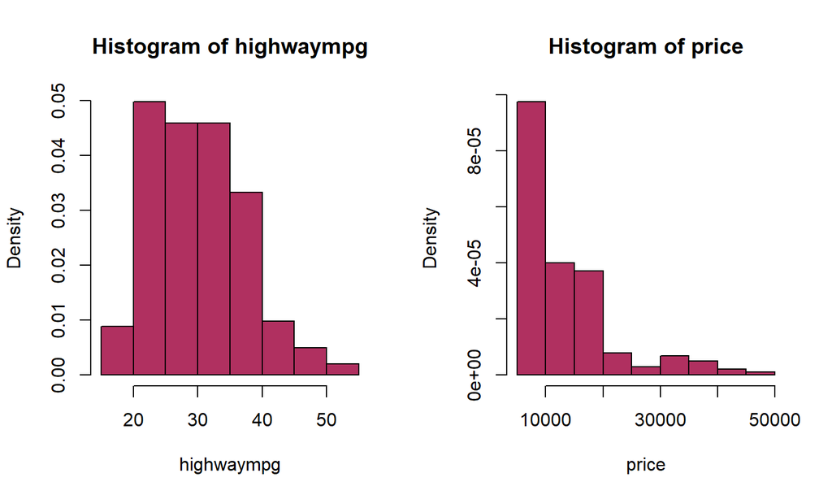

- Now we will see the presence of outliers in each numerical variables.

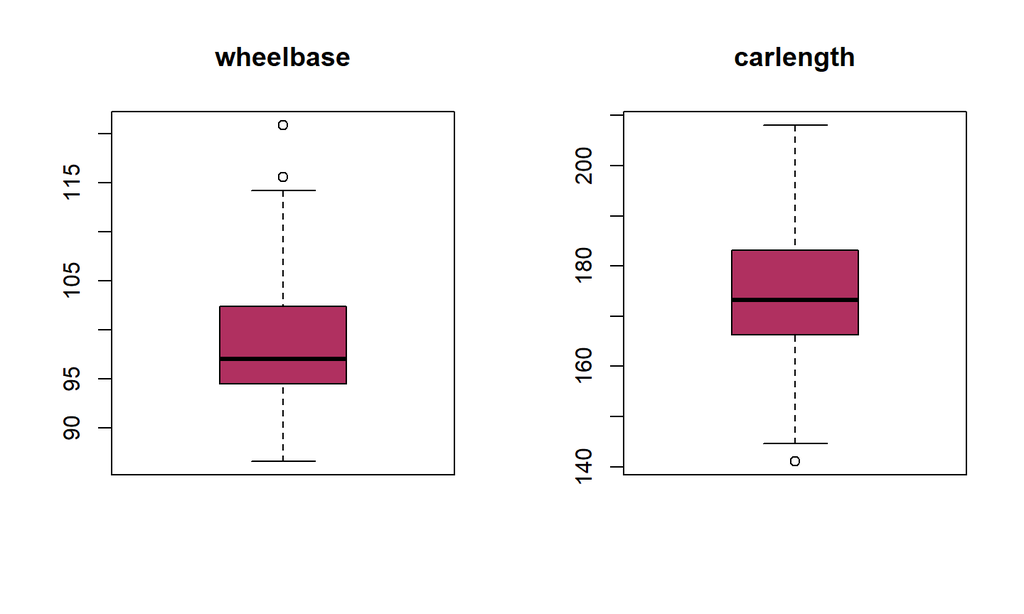

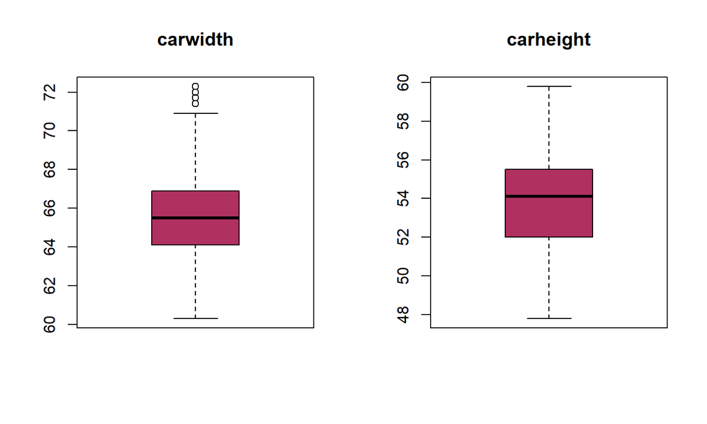

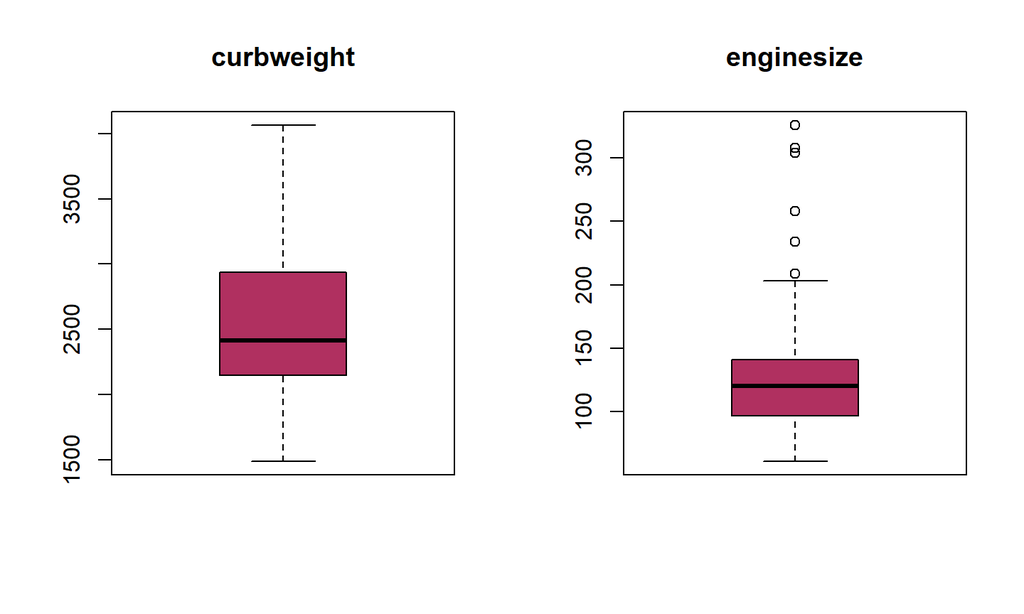

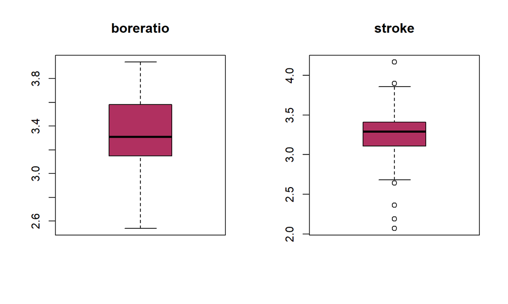

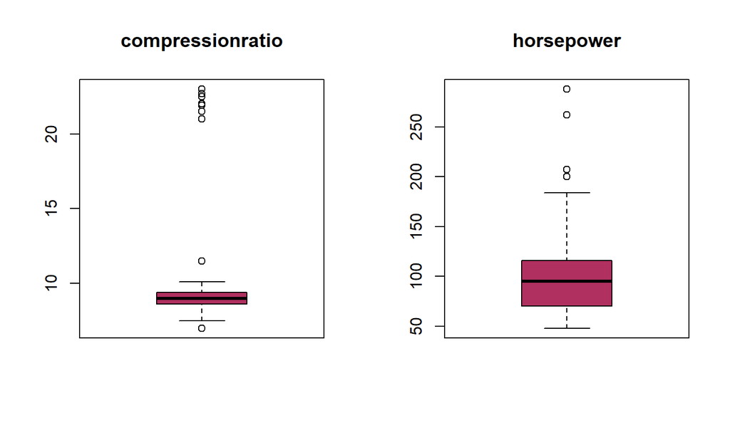

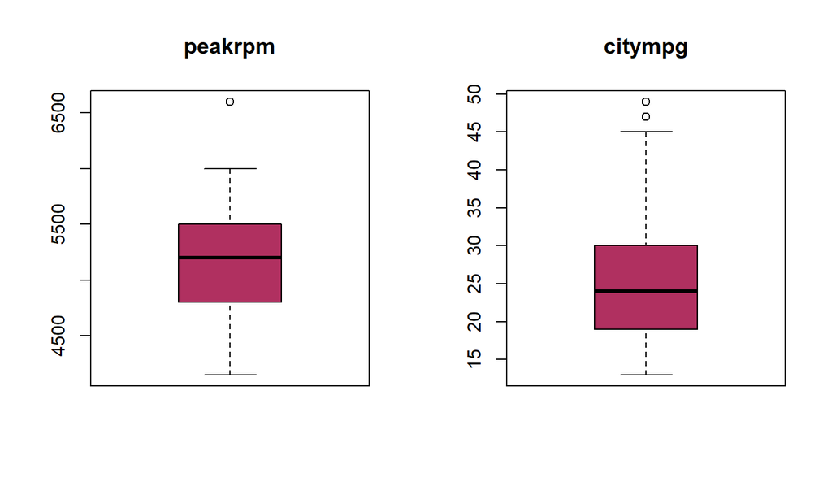

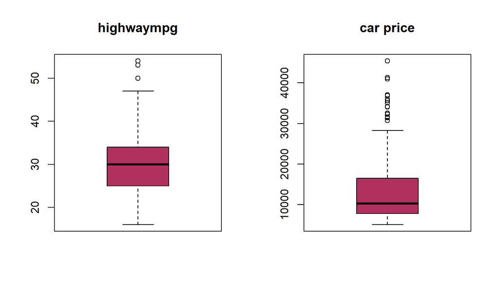

## Relationship Between ”carprice” and Different Numerical Variables

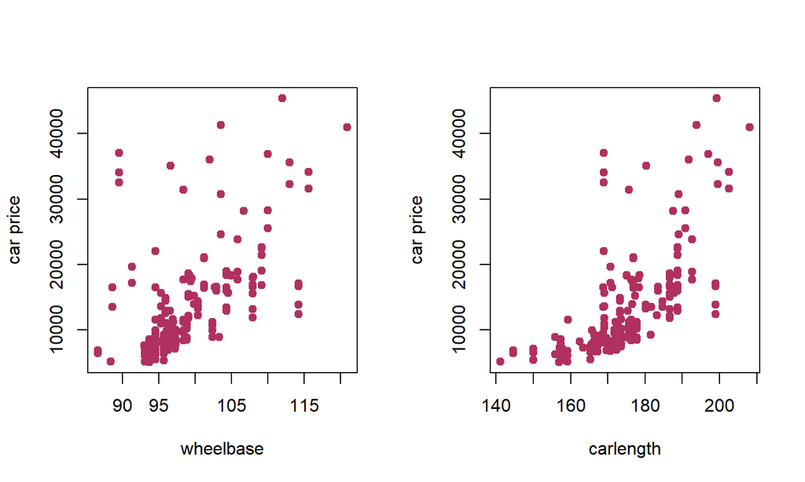

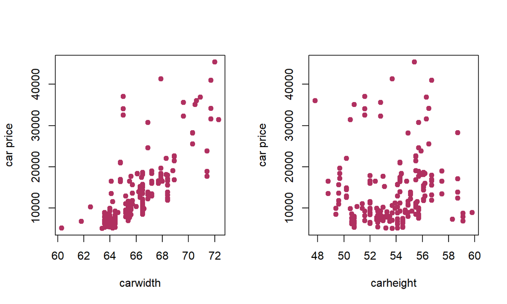

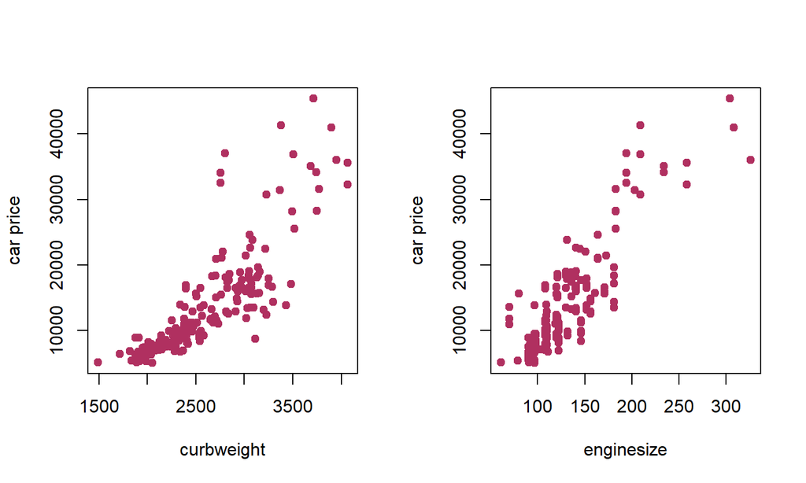

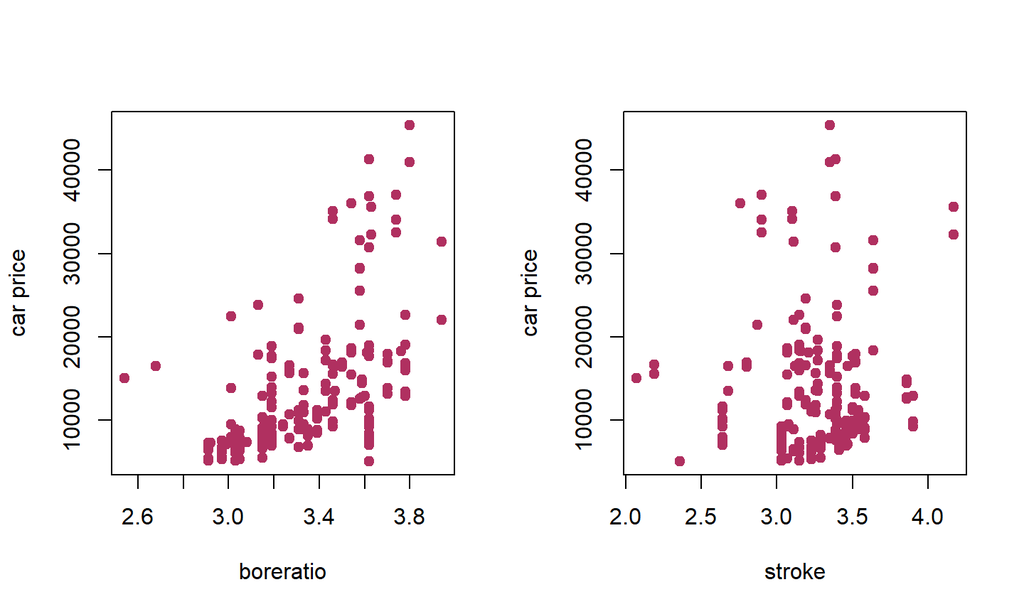

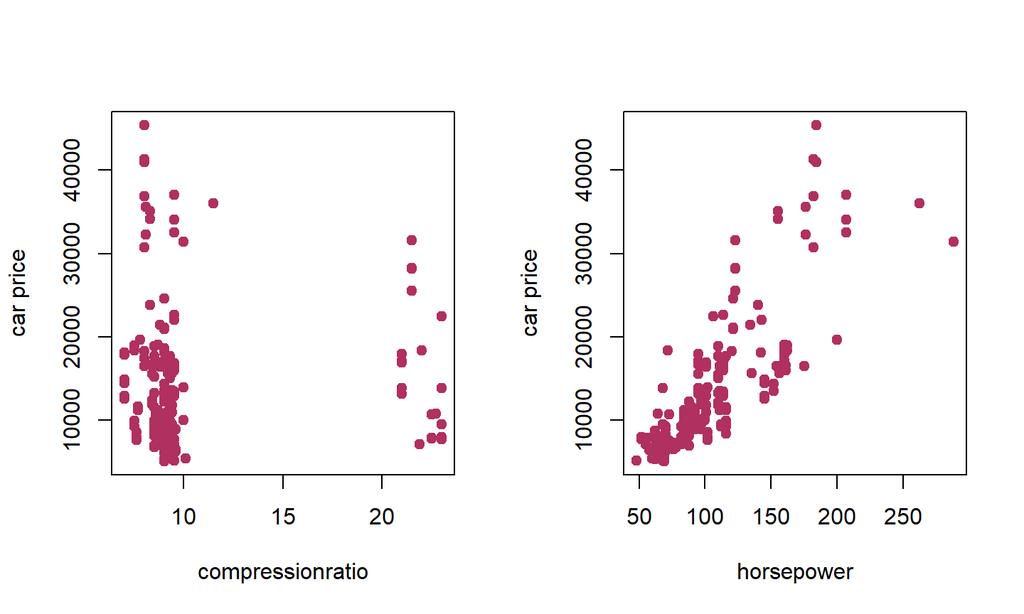

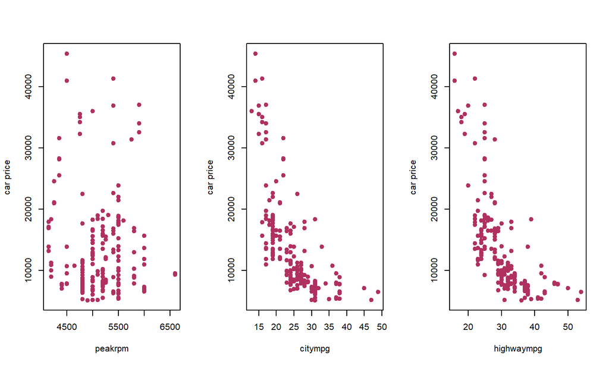

## Relationship Between ”carprice” and Different Categorical Variables

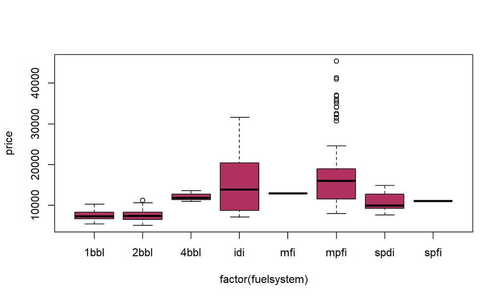

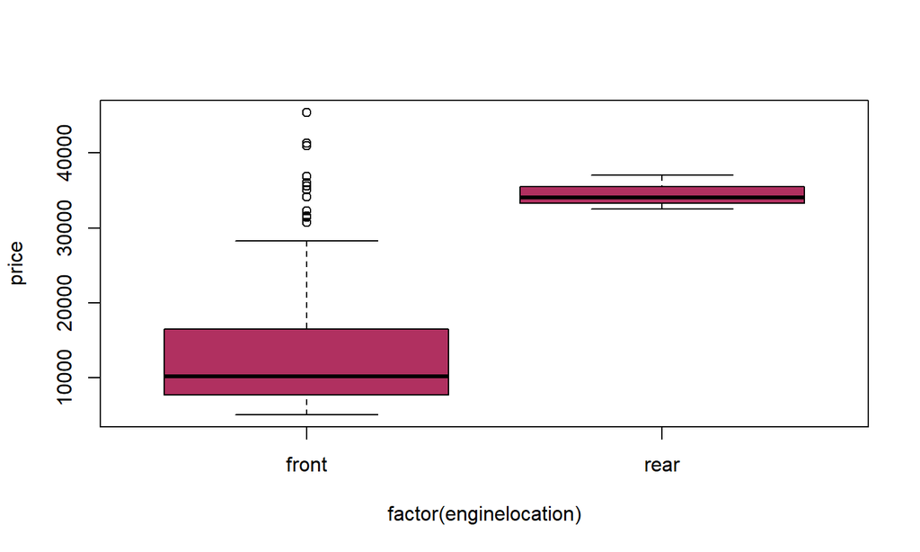

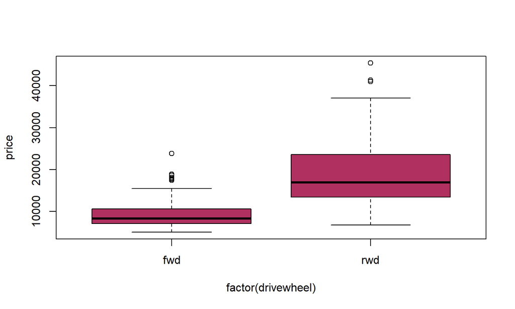

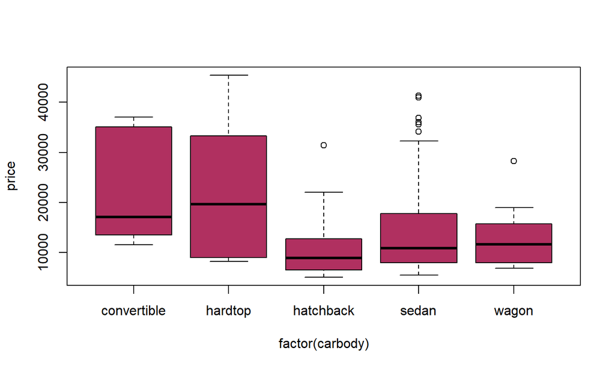

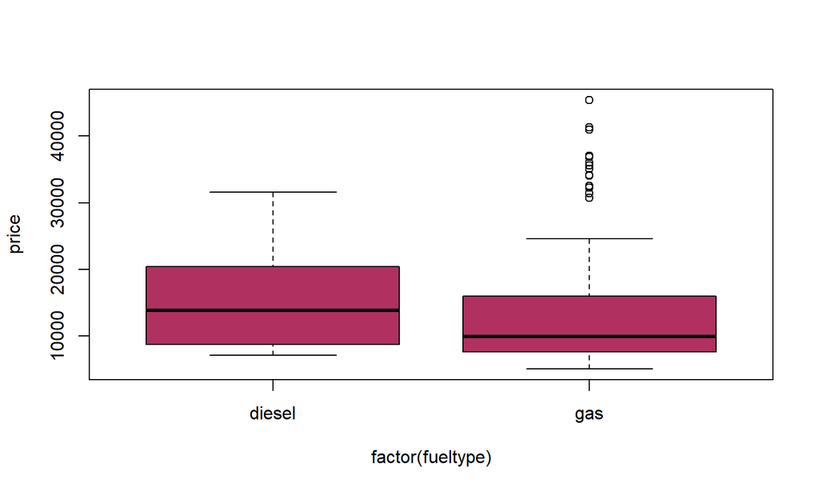

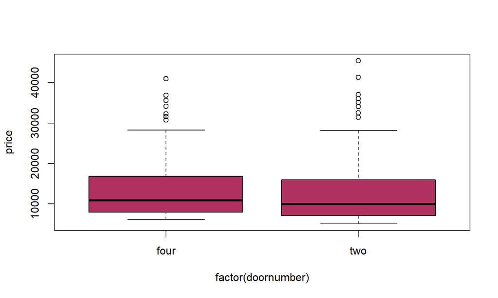

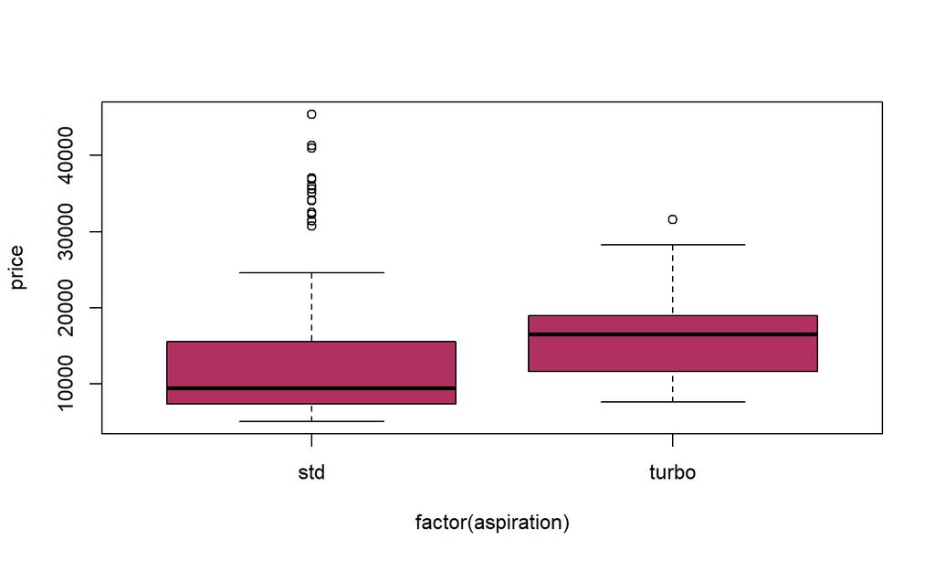

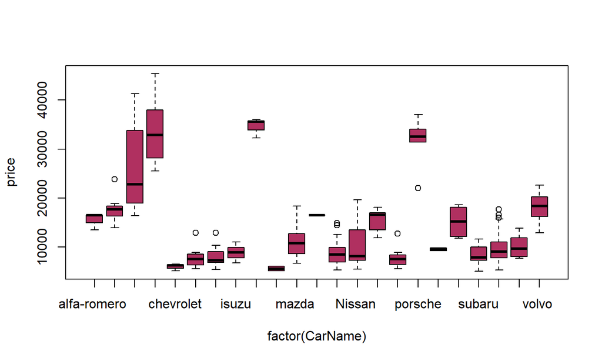

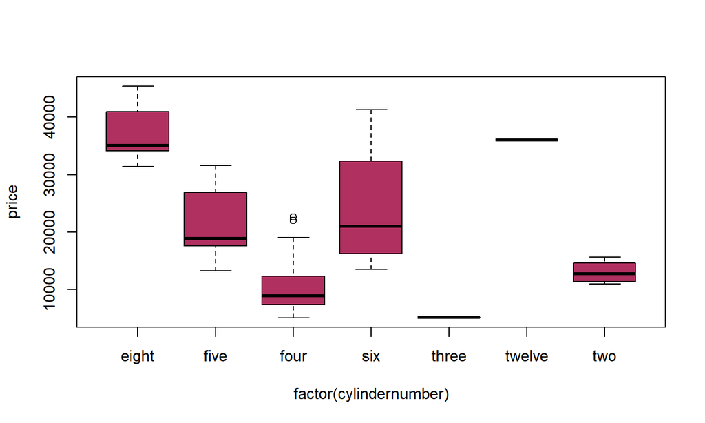

## Checking Collinearity in Numerical Predictors

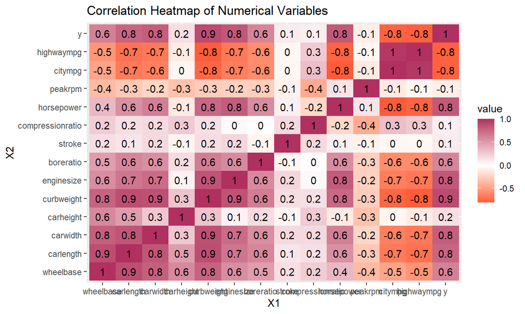

## Transformation of Categorical Variables

- Now we convert the categorical variables into dummy variables so that we can use it as a regression model.
- And we delete the first column dummy set of each variable to remove multicollinearity from the new dataset.
- After creating dummy variables we have now total 63 predictors.

## Breaking the Dataset into Train Set and Test Set

- Now I want to predict car price based on my given data.
- So I have decided to break my dataset into train set and test set.
- The original dataset has 205 data points.
- The train set contains 80% of data and 20% in test set.

## Model Building and Model Modification

- Now we want to fit different model on the train set and select the best one.
- Here,our variable of interest is price of car.

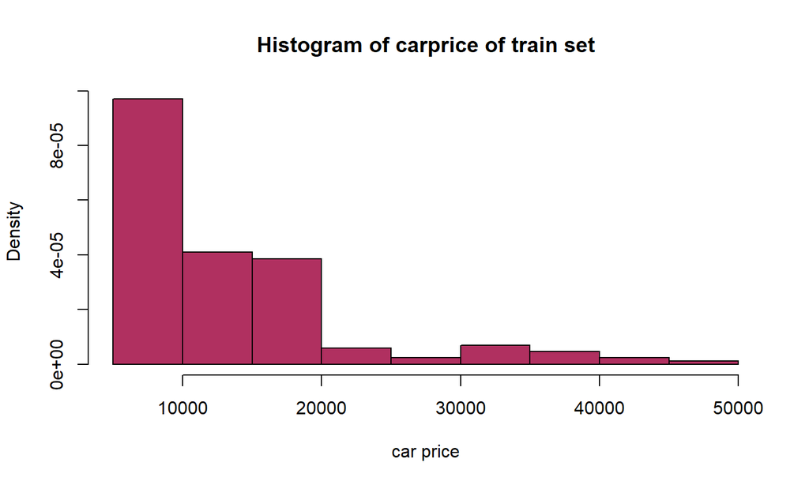

- Clearly, the price is positively skewed.
- So I do log transformation of price and consider that as my response variable.

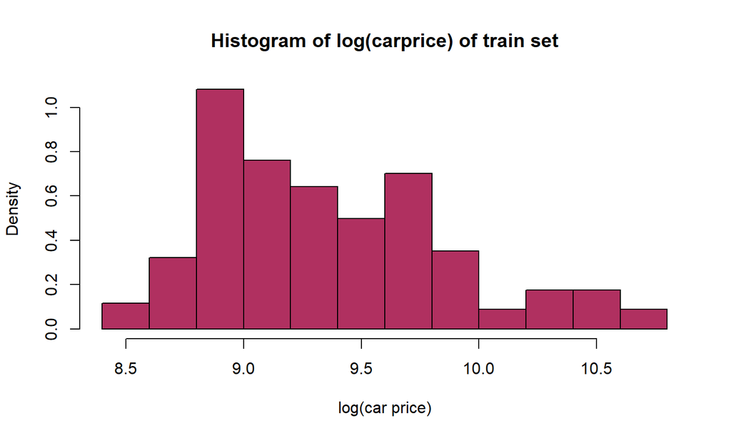

- After log transformation we can see that the skewness has been reduced.

## Model 1:Considering All the Predictors

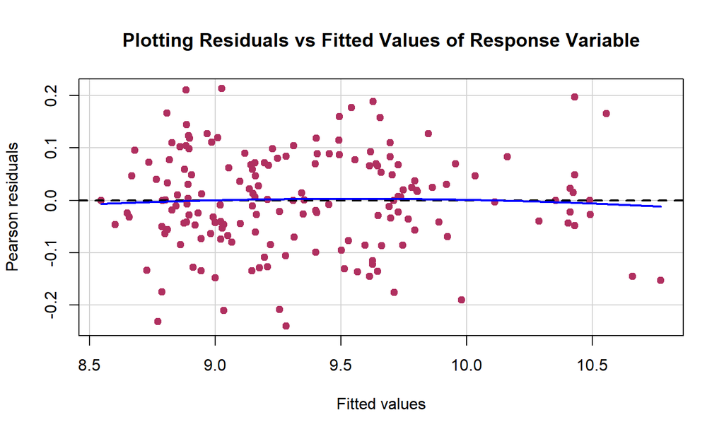

- The residuals are randomly scattered.

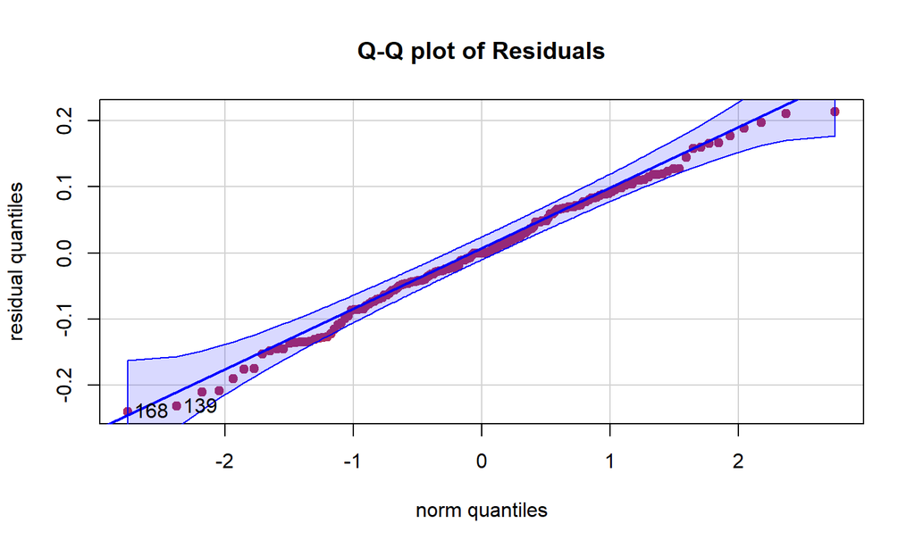

```
## 168 139
## 140 115
```

- The residual quantiles coincides more or less with actual normal quantiles.